# 4 Pahoinpitely- ja ryöstörikokset

*Matti Näsi*

## 4.1 Tiivistelmä

- Vuonna 2024 poliisin tietoon tuli 41 498 pahoinpitelyrikosta ja 381 henkirikoksen yritystä. Poliisin kirjaamien pahoinpitelyrikosten määrä pysyi samalla tasolla edellisvuoteen verrattuna.
- Poliisin tietoon tuli 2 593 ryöstörikosta vuonna 2024. Tilastoitujen ryöstörikosten määrä laski hieman edellisvuoteen verrattuna.
- Tilastoidun väkivallan määrään ja kehitykseen vaikuttaa paitsi väkivaltatapausten määrä myös väestön ilmoitusalttius, poliisikontrollin kohdistaminen ja teho sekä lainmuutokset.
- Vuoden 2023 kansallisen rikosuhritutkimuksen mukaan 3,9 prosenttia aikuisista joutui vuoden aikana vammaan johtaneen väkivallan kohteeksi. Vähintään läimäisyn sisältävää väkivaltaa oli kokenut 5,5 prosenttia 15–74-vuotiaista. Fyysistä väkivaltaa kokeneiden osuus pysyi samalla tasolla kuin vuoden 2021 tutkimuksessa.
- Nuoret ovat vanhempia ikäryhmiä useammin epäiltynä väkivaltarikoksista. Epäillyt ovat useimmiten miehiä. Nuoret joutuvat myös väkivaltarikoksen uhriksi selvästi vanhempia ikäryhmiä useammin sekä kyselytutkimusten että poliisitilastojen mukaan.
- Uhritutkimusten mukaan naiset kokevat kokonaisuutena tarkastellen väkivaltaa ja uhkailua miehiä enemmän. Vakavassa poliisin tietoon tulleessa väkivallassa uhrit sen sijaan ovat useammin miehiä.
- Vuonna 2024 pahoinpitelyrikosten taso oli korkein Helsingin ja Itä-Uudenmaan poliisilaitosalueilla ja matalin Pohjanmaalla ja Ahvenanmaalla. Kaikkiaan pahoinpitelyrikosten taso on hieman korkeampi kaupunkimaisissa kunnissa, erityisesti pääkaupunkiseudulla.

Edellisessä luvussa tarkasteltiin henkirikoksia. Tässä luvussa aiheena ovat pahoinpitelyrikokset, henkirikoksen yritykset ja ryöstörikokset. Tahallista fyysistä väkivaltaa esiintyy myös esimerkiksi virkamiehen väkivaltaisen vastustamisen ja raiskausrikosten yhteydessä. Rajanveto perinteisen väkivaltarikollisuuden ja muiden tahallisten henkeä ja terveyttä vaarantavien tekojen välillä on osin sopimuksenvarainen.

## 4.2 Tietolähteet

Seuraavassa tarkastellaan osoittimia, joihin jakson tiedot pahoinpitely- ja ryöstörikollisuudesta perustuvat. Pahoinpitely- ja ryöstörikollisuuden tärkeimmät osoitinjärjestelmät ovat:

1. Rekisteritiedot. Keskeisimpänä tietolähteenä käytetään Tilastokeskuksen julkaisemaa rikos- ja pakkokeinotilastoa, joka sisältää tietoja poliisin, Tullin ja rajavartiolaitoksen tietoon tulleista rikoksista sekä epäillyistä tekijöistä ja uhreista. Tilasto perustuu pääosin poliisin keräämiin tietoihin, joten sitä voidaan jatkossa nimittää “poliisitilastoksi”. Lisäksi käytetään eräitä muita tietolähteitä kuten rikosten teonpiirteiden seuranta- ja tutkimusrekisteriä sekä henkirikollisuuden seurantajärjestelmää. Osion lopussa esitellään väkivaltaan liittyviä terveydenhuollon rekisterimerkintöjä terveydenhuollon hoitoilmoitusrekisterin (Terveys-Hilmo) ja perusterveydenhuollon avohoidon käynteihin liittyvän hoitoilmoitusrekisterin (Avohilmo) perusteella.
2. Uhritutkimukset. Kattavimman kuvan väestön uhrikokemuksista tarjoaa Kansallinen rikosuhritutkimus, joka on kohdistettu 15–74-vuotiaille Suomessa asuville henkilöille. Tutkimuksessa selvitetään väestön joutumista väkivallan, uhkailujen ja omaisuusrikosten kohteeksi. Nykymuotoinen kysely on ollut käytössä vuodesta 2012 lähtien, ja kysely on toteutettu vuosittain vuoteen 2021 asti, jonka jälkeen se toteutetaan joka toinen vuosi. Tätä edeltävältä ajalta tietolähteenä ovat kansalliset uhritutkimukset, joita toteutettiin vuosina 1980–2009. Nykymuotoinen ja ennen vuotta 2012 kerätty uhritutkimustieto eivät ole suoraan vertailukelpoisia menetelmällisten erojen takia, ja tämä on pidettävä mielessä erityisesti aikasarjoja tarkasteltaessa (ks. Sirén 2011). Lisäksi viime vuosikymmeninä on tehty valtakunnallisia erityisryhmiin suunnattuja kyselytutkimuksia väkivallasta. Niissä on käsitelty lasten ja nuorten kokemaa väkivaltaa sekä naisiin kohdistunutta väkivaltaa.

Osoitinjärjestelmien väkivallan yleisyyttä koskevien tietojen vertailtavuutta vaikeuttaa se, että mittausyksiköt ovat toisistaan poikkeavat: poliisitilasto mittaa poliisin tietoon tulleiden väkivallantekojen määrää, kyselytutkimukset puolestaan pääsääntöisesti mittaavat väkivallan uhriksi joutuneiden osuutta väestötasolla. Osin tästä syystä myös lähteiden pahoinpitelyrikollisuuden *trendistä* antamat tiedot saattavat poiketa. Vertailtavuutta vaikeuttavat myös muut tekijät, joista tärkein on piilorikollisuus.

Piilorikollisuuden muodostavat kaikki ne rikokset, jotka eivät päädy poliisin tai muiden viranomaisten tietoon eivätkä tästä syystä näy viranomaistilastoissa. Tosiasiallinen rikollisuus (kokonaisrikollisuus) on sekä pahoinpitely- että ryöstörikollisuudessa tuntuvasti suurempaa kuin poliisin tietoon tuleva rikollisuus. Uhritutkimusten mukaan sekä pahoinpitelyrikoksista että ryöstörikoksista pääosa jää tulematta ilmi. Viranomaistilastojen ulkopuolelle (piilorikollisuus) jää sitä suurempi osa teoista, mitä lievemmästä väkivallasta on kyse.

## 4.3 Väkivaltarikollisuuden kehitys

### 4.3.1 Poliisin tietoon tullut rikollisuus

*Pahoinpitelyrikokset.* Tilastoitujen pahoinpitelyrikosten kokonaismäärä vuonna 2024 oli 41 498 (taulukko 1). Poliisin kirjaamien pahoinpitelyrikosten määrä pysyi samalla tasolla edellisvuoteen verrattuna (kuvio 1). Viimeisen noin viidentoista vuoden tarkastelujaksolla merkittävin aiempi tasomuutos poliisin tilastoimassa väkivallassa tapahtui vuonna 2011 väkivallan syyteoikeuden muutosten myötä. Silloisen muutoksen myötä kasvua tapahtui erityisesti perusmuotoisina ja lievinä pahoinpitelyinä tutkituissa teoissa. Vuonna 2011 kasvua nähtiin poliisin tietoon tulleissa rikoksissa, mutta myös syylliseksi epäiltyjen määrä kasvoi silloin selvästi. Vuoden 2022 jälkeen kasvun taustalla on myös lisääntyneet ilmoitukset erityisesti perusmuotoisten ja lievien pahoinpitelyjen kohdalla. Tarkempi tarkastelu paljastaa, että kasvun taustalla on erityisesti alle 15-vuotiaiden epäiltyjen määrän selkeä lisääntyminen.

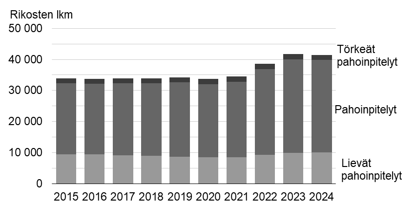

Pahoinpitelyrikosten määrä on pysynyt suhteellisen vakaana vuosien 2013-2021 välillä. Vuonna 2022- 2024 rikosten lukumäärä on kasvanut.

**Kuvio 1** Poliisin tietoon tulleet pahoinpitelyrikokset vuosina 2015–2024. *Lähde*: Tilastokeskus, rikos- ja pakkokeinotilasto (Tilastokeskus 2025a)

*Henkirikoksen yritykset.* Henkirikoksen yrityksinä tilastoitujen rikosten määrä vuonna 2024 oli 381 (taulukko 1), joka on käytännössä samalla tasolla aiempiin vuosiin verrattuna. Henkirikoksen yritysten tilastoja tarkasteltaessa tulkittaessa on huomioitava, että rajanveto tapon yrityksen ja törkeän pahoinpitelyn välillä on kirjaamisvaiheessa usein tulkinnanvarainen, joten sillä voi olla vaikutuksia lopullisiin tilastoihin (ks. tarkemmin Rikollisuustilanne 2009).

*Ryöstörikokset.* Vuonna 2024 poliisin tietoon tuli 2 593 ryöstörikosta (RL 31:1–2) (taulukko 1). Tilastoitujen ryöstörikosten määrä hieman laski edellisvuoteen nähden. Poliisin tietoon tulleiden törkeiden ryöstöjen määrä on kasvanut suhteessa perusmuotoisia ryöstöjä hieman voimakkaammin viimeisten vuosien osalta. Tilastokeskuksen rikos- ja pakkokeinotilasto mahdollista poliisin tietoon tulleen rikollisuuden tarkastelun aina vuodesta 1980 lähtien. Taulukon ulkopuolelta voidaankin todeta, että kokonaisuudessaan poliisin tietoon tulleiden ryöstörikosten määrä vuonna 2023 on mittaushistorian korkeimmalla tasolla.

**Taulukko 1** Eräät poliisin tietoon tulleet väkivaltarikokset vuosina 2015–2024

|  | **2015** | **2016** | **2017** | **2018** | **2019** | **2020** | **2021** | **2022** | **2023** | **2024** |
| --- | --- | --- | --- | --- | --- | --- | --- | --- | --- | --- |
| Henkirikoksen yritys | 299 | 311 | 348 | 355 | 330 | 388 | 376 | 350 | 356 | 381 |
| Lievä pahoinpitely | 9 493 | 9 377 | 9 190 | 8 988 | 8 696 | 8 435 | 8 552 | 9 279 | 9 850 | 10 078 |
| Pahoinpitely | 22 818 | 22 800 | 23 072 | 23 347 | 23 957 | 23 513 | 24 300 | 27 591 | 30 164 | 29 764 |
| Törkeä pahoinpitely | 1 563 | 1 592 | 1 585 | 1 616 | 1 594 | 1 762 | 1 671 | 1 733 | 1 801 | 1 656 |
| **Pahoinpitelyrikokset yhteensä** | 33 874 | 33 769 | 33 847 | 33 951 | 34 247 | 33 710 | 34 523 | 38 603 | 41 815 | 41 498 |
| Pahoinpitely ja vammantuottamus | 124 | 100 | 106 | 106 | 108 | 81 | 88 | 71 | 73 | 68 |
| Ryöstö | 1 284 | 1 396 | 1 379 | 1 404 | 1 465 | 1 553 | 1 456 | 1 879 | 2 173 | 2 015 |
| Törkeä ryöstö (ml. valmistelu) | 266 | 277 | 264 | 304 | 347 | 448 | 446 | 457 | 560 | 578 |
| **Ryöstörikokset yhteensä** | 1 550 | 1 673 | 1 643 | 1 708 | 1 812 | 2 001 | 1 902 | 2 336 | 2 733 | 2 593 |

*Lähteet*: Tilastokeskus, rikos- ja pakkokeinotilasto (Tilastokeskus 2025a).

### 4.3.2 Uhritutkimukset

Kansallinen rikosuhritutkimus (KRT) tuottaa vuosittain tietoa suomalaisten kokemasta väkivallasta. Vuoden 2023 kyselyn mukaan 5,5 prosenttia 15–74-vuotiaista suomalaisista oli vuoden aikana joutunut läimäisyn tai sitä vakavamman väkivallan kohteeksi. Uhkailua oli kokenut noin joka kymmenes. Sellaista väkivaltaa, josta aiheutui vamma eli vähintään mustelma tai ruhje, oli vuoden aikana kokenut 3,9 prosenttia (Beuker & Näsi 2024). Seuraava, vuotta 2025 koskeva Kansallinen rikosuhritutkimus toteutetaan vuoden 2026 alussa.

Väkivaltakokemuksissa tapahtuneista pidemmän aikavälin muutoksista saadaan tietoa Kansallisista uhritutkimuksista (1980–2009) ja Kansallisesta rikosuhritutkimuksesta (2012–2023). Tässä yhteydessä fyysisellä väkivallalla tarkoitetaan erilaisia tekomuotoja, joista osa on varsin lieviä – tarkastellut väkivallan muodot vaihtelevat tönimisestä lyömiseen ja asetta käyttäen tehtyyn väkivaltaan. Fyysistä väkivaltaa kokeneiden osuus pysyi 1988–2009 välisenä aikana lähes samana, samoin vamman aiheuttanutta väkivaltaa kokeneiden osuus (kuvio 2) (Sirén ym. 2010; Sirén & Honkatukia 2005).

Vuosien 2012–2023 luvut ovat uudesta Kansallisesta rikosuhritutkimuksesta eikä niitä voi suoraan verrata vuoden 2009 ja sitä edeltäviin lukuihin. Uusi, vuodesta 2012 kerätty KRT-järjestelmä näyttää tuottavan selvästi korkeamman, noin kaksinkertaisen, arvion väkivallan yleisyydestä. Tämä johtunee vaihtuneesta tiedonkeruumenetelmästä: vuotta 2012 edeltäneet uhritutkimukset toteutettiin puhelinhaastatteluilla ja uusi rikosuhritutkimus postikyselyllä, jonka on todettu antavan puhelinkyselyjä korkeampia estimaatteja uhrikokemusten yleisyydestä (Heiskanen 1998; Siren 2011; Laaksonen & Heiskanen 2014). Vuosina 2012–2019 vamman aiheuttanut väkivalta pysyi varsin samalla tasolla, mutta laski selvästi vuonna 2020; kuitenkin vuodesta 2021 eteenpäin palattiin koronapandemiaa edeltävälle tasolle. Myös fyysisen väkivallan yleisyys laski selvästi vuonna 2020, mutta sen jälkeen väkivaltaa kokeneiden osuus on jäänyt kuitenkin pandemiaa edeltäneitä vuosia alhaisemmalle tasolle. Vaikuttaa siis siltä, että aiempaa pienempi osuus vastaajista on joutunut väkivallan uhriksi. Muutos näkyy kuitenkin ennen kaikkea lievemmän väkivallan laskuna, ei niinkään vamman aiheuttaneen väkivallan osalta.

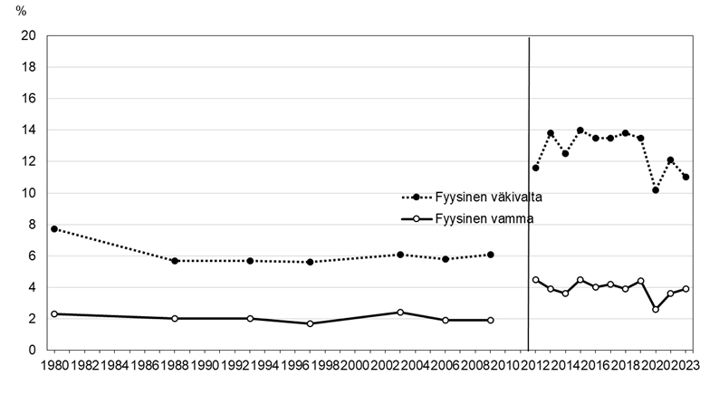

Fyysisen väkivallan kohteeksi joutuneiden osuus 15-74 vuotiaista on vaihdellut kymmenen ja neljäntoista prosentin välillä vuosina 2012-2023. Fyysisen vamman saaneiden osuus vastaavalla aikävälillä on ollut vuosittain noin neljä prosenttia.

**Kuvio 2** Väkivallan kohteeksi vuoden aikana joutuneita 1980–2023 (% 15–74-vuotiaista). *Lähteet*: Sirén ym. 2010 ja KRT 2012–2024. Vuodesta 2012 eteenpäin tiedot eivät ole täysin vertailukelpoisia aikaisempiin tutkimuksiin nähden.

On kuitenkin huomioitava, että väkivaltarikollisuus ja erityisesti törkeä väkivaltarikollisuus keskittyy suhteellisen pieneen sosiaalisesti syrjäytyneiden päihteiden väärinkäyttäjien ryhmään, jossa myös riski joutua väkivallan uhriksi on moninkertainen valtaväestöön nähden (Lehti 2020; Smolej 2014). Uhritutkimuksilla ei juurikaan saada tietoa tämän ryhmän väkivaltakokemuksissa tapahtuvista muutoksista. Paras tietolähde väkivallan ongelmaryhmässä tapahtuvasta kehityksestä on törkeää väkivaltaa (henkirikoksen yrityksiä ja törkeitä pahoinpitelyitä) koskevat viranomaistilastot. Törkeimmässä väkivallassa vammojen laadun takia ilmituloaste on yleensä suhteellisen korkea, eikä ilmitulossa ole suuria eroja väestöryhmien välillä.

## 4.4 Väkivaltarikosten piirteitä

Seuraavat tarkastelut perustuvat sekä poliisin tietoon tulleeseen rikollisuuteen (Tilastokeskuksen poliisin tietoon tullutta väkivaltaa kuvaavat tilastot), että kokonaisrikollisuustutkimukseen (vuosien 1980–2009 Kansallisten uhritutkimusten aineistot ja vuosina 2012–2023 toteutetun Kansallisen rikosuhritutkimuksen aineistot).

### 4.4.1 Ikä ja sukupuoli

*Väkivalta ja ikä.* Sekä väkivallan tekeminen että sen uhriksi joutuminen painottuvat nuoriin ikäryhmiin. Tästä yleiskuvasta poikkeavat jossain määrin henkirikokset, joissa sekä tekijöiden että uhrien keskimääräinen ikä on muuta väkivaltarikollisuutta korkeampi. Koska ikäryhmien koot vaihtelevat, tekijöiden ja määrä on suhteutettu saman ikäisen väestöryhmän kokoon. Kuvioissa 3 ja 4 on tarkasteltu pahoinpitelyrikoksista epäiltyjä iän mukaan väestön 10 000 henkeä kohti. Tarkasteluun on otettu 9–69-vuotiaat. Rajauksena perusteena on se, että alle 10-vuotiaita ja yli 70-vuotiaita epäiltyjä on erittäin vähän.

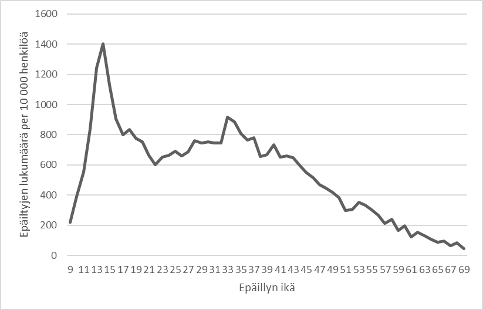

Pahoinpitelyrikoksiin syyllistyvät todennäköisimmin 14v., minkä jälkeen rikosepäilyt vähenevät vanhempiin ikäryhmiin siirryttäessä.

**Kuvio 3** Pahoinpitelyrikoksista epäiltyjä epäillyn iän mukaan (9–69-vuotiaat) 10 000 henkeä kohti, viranomaisten tietoon vuonna 2024 tulleet rikokset. *Lähteet*: Tilastokeskus, rikos- ja pakkokeinotilasto (Tilastokeskus 2025a).

Kuvion 3 perusteella havaitaan, että pahoinpitelyrikoksiin syylliseksi epäilty on todennäköisimmin 14-vuotias. Näin oli myös jo muutamina edeltävinä vuosina. Viime vuosien muutos on kuitenkin merkittävä, sillä aiempien vuosikymmenten tarkastelu paljastaa, että yleisimmin pahoinpitelyrikoksista epäilty on ollut noin 20-vuotias. Näin ollen viimeiset neljä vuotta ovat näyttäytyneet varsin poikkeuksellisina poliisin tietoon tulleen väkivallan osalta.

Uhritutkimusten mukaan eniten väkivaltakokemuksia on nuorimmilla vastaajilla. Kuviosta 4 ilmenee vuoden aikana fyysistä väkivaltaa kokeneiden osuus sekä fyysisen haitan aiheuttanutta väkivaltaa kokeneiden osuus ikäryhmittäin edeltävän vuoden aikana vuoden 2023 kyselyssä. Tässä yhteydessä fyysisellä väkivallalla tarkoitetaan kiinni tarttumista, tönimistä, lyömistä tai tätä vakavampaa väkivaltaa. Kuviosta havaitaan, että mitä vanhemmasta ikäryhmästä on kysymys, sitä harvinaisempia väkivaltakokemukset ovat. Vuoden 2023 tutkimuksessa noin 20 prosenttia 15–24-vuotiaista ilmoitti joutuneensa fyysisen väkivallan kohteeksi vuoden aikana, kun vastaava osuus 55–74-vuotiaiden ryhmässä oli noin viisi prosenttia. Jos tilannetta verrataan vuoden 2021 kyselyyn, niin väkivaltaa kokeneiden vastaajien osuus laski selvästi nuorimmassa ikäryhmässä noin viisi prosenttiyksikköä, mutta muiden ikäryhmien osalta uhriosuudet olivat varsin samalla tasolla kuin edeltävässä, vuoden 2021 kyselyssä. Vamman aiheuttaneen väkivallan osalta muutoksia havaittiin 25–34-vuotiaiden ikäryhmässä, jossa vuoden 2023 uhriosuus kasvoi kolme prosenttiyksikköä verrattuna vuoden 2021 kyselyn tuloksiin. Muiden ikäryhmien osalta ei havaittu juurikaan muutoksia.

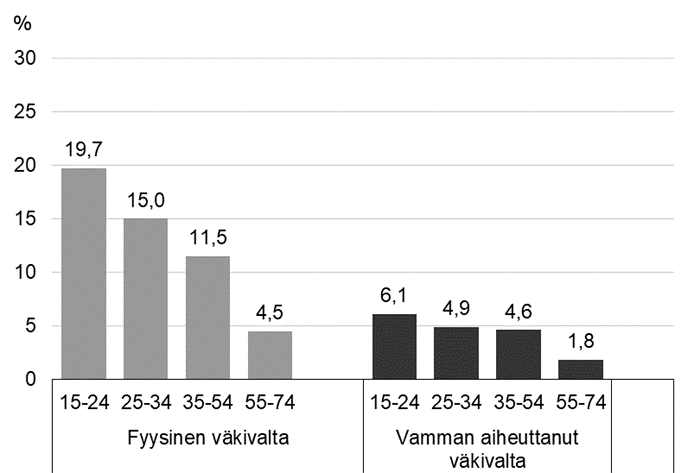

Sisältö kerrottu edeltävässä tekstiosuudessa.

**Kuvio 4** Väkivallan kohteeksi vuoden aikana joutuneet 15–74-vuotiaat ikäryhmän mukaan vuonna 2023 (%). *Lähde:* Kansallinen rikosuhritutkimus (Beuker & Näsi 2024)

Kuten pahoinpitelyrikollisuudessa myös viranomaisten tietoon tulleessa ryöstörikollisuudessa tekijät ja uhrit ovat tyypillisimmin nuoria henkilöitä. Vuonna 2024 ryöstöistä syylliseksi epäillyistä 77 prosenttia oli alle 30-vuotiaita. Alle 30-vuotiaiden osalta havaitaan myös se, että puolet syylliseksi epäillyistä oli alle 18-vuotiaita. Vuonna 2024 alle 15-vuotiaiden epäiltyjen määrä oli 388, mikä on noin 15 prosenttia vähemmän edelliseen vuoteen verrattuna. Kokonaisuudessaan alle 15-vuotiaiden epäiltyjen osuus kaikista ryöstörikoksista oli 14 prosenttia vuonna 2024. Myös uhreista enemmistö oli alle 30-vuotiaita: vuonna 2024 alle 30-vuotiaiden uhrien osuus oli 57 prosenttia. Uhreista 11 prosenttia oli alle 15-vuotiaita. Kokonaisuudessaan ryöstörikoksista epäiltyjen ikärakenne painottuu hieman voimakkaammin nuorempiin ikäryhmiin kuin ryöstörikosten uhrien ikärakenne.

*Väkivalta ja sukupuoli.* Suurin osa poliisin tietoon tulleiden väkivaltarikosten tekijöistä on miehiä (kuvio 5). Vuonna 2024 poliisin tietoon tulleissa perusmuotoisissa pahoinpitelyrikoksissa 80 prosenttia syyllisiksi epäillyistä oli miehiä. Osuus oli 74 prosenttia lievissä pahoinpitelyissä ja 81 prosenttia törkeissä pahoinpitelyissä. Miesten osuus oli vielä suurempi henkirikoksen yrityksissä (83 %) sekä henkirikoksissa (89 %).

Myös väkivaltarikosten uhreista suurempi osa on miehiä, sukupuolten välinen ero on pienempi kuin epäiltyjä koskevassa tarkastelussa. Vuonna 2024 perusmuotoisten pahoinpitelyrikosten uhreista 57 prosenttia oli miehiä. Lievissä pahoinpitelyissä mies- ja naisuhreja oli lähes yhtä paljon, mutta vakavammissa väkivaltarikoksissa miesten osuus uhreista oli huomattavasti suurempi.

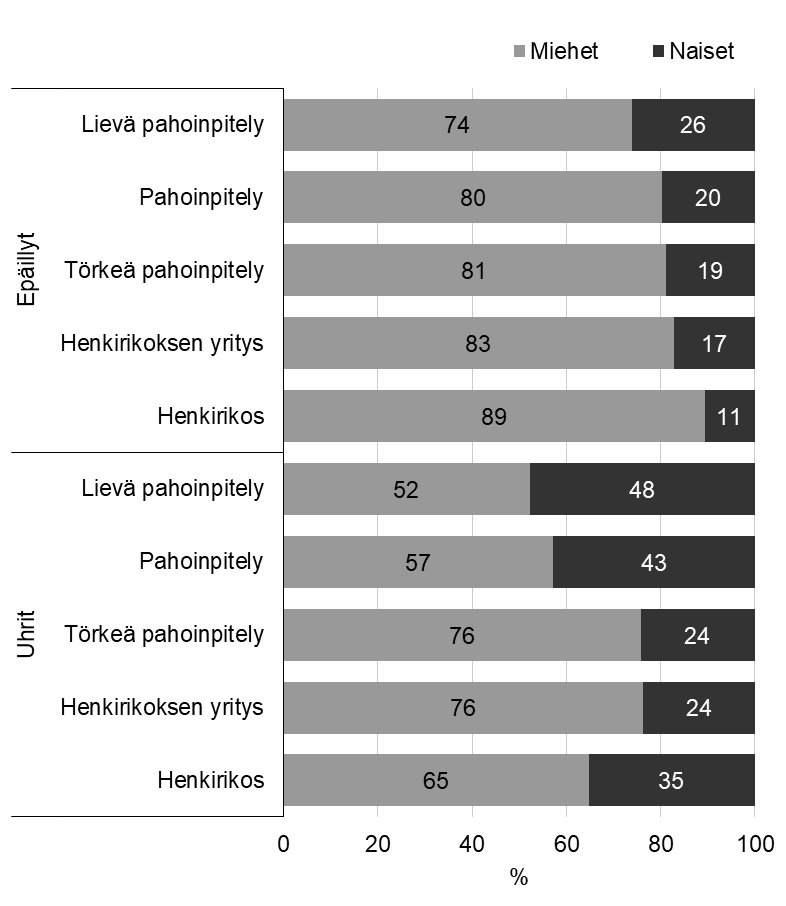

Sisältö kerrottu edeltävässä tekstiosuudessa.

**Kuvio 5** Eräiden väkivaltarikosten epäiltyjen ja uhrien sukupuolijakauma vuonna 2024. *Lähde*: Tilastokeskus, rikos- ja pakkokeinotilasto (Tilastokeskus 2025a).

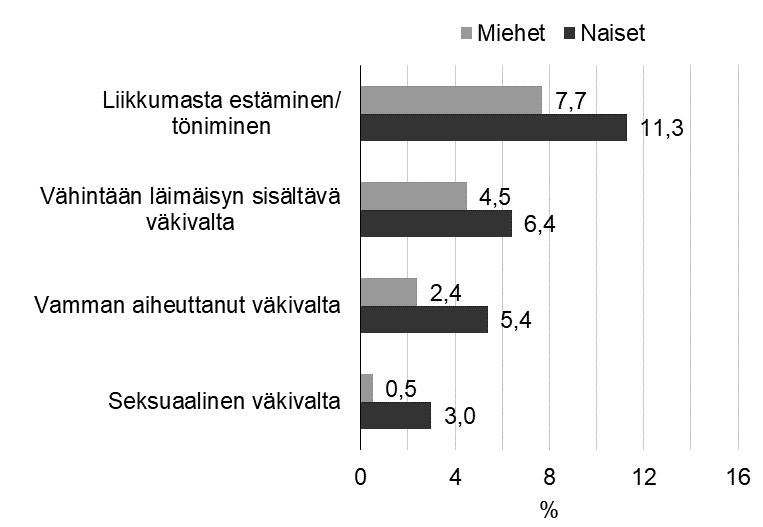

Sisältö kerrottu edeltävässä tekstiosuudessa.

**Kuvio 6** Väkivallan kohteeksi vuoden aikana joutuneet 15–74-vuotiaat sukupuolen mukaan vuonna 2023 (%). *Lähde*: Kansallinen rikosuhritutkimus (Beuker & Näsi 2024)

Osapuolten suhde

Uhritutkimusten mukaan (kuvio 7) sekä miehiin että naisiin kohdistuneessa fyysisessä väkivallassa tyypillisin tekijä on tuntematon tai puolituttu henkilö (Beuker & Näsi 2024). Havainto koskee niin lievempiä tekomuotoja kuin vammankin aiheuttanutta väkivaltaa.

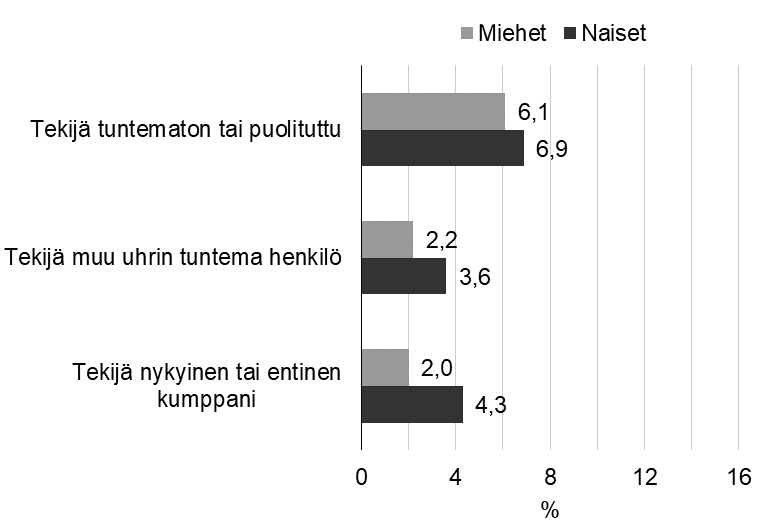

**Kuvio 7** Vuoden aikana fyysisen väkivallan kohteeksi joutuneet 15–74-vuotiaat sukupuolen ja väkivallan tekijän mukaan vuonna 2023 (%). *Lähde*: Kansallinen rikosuhritutkimus (Beuker & Näsi 2024)

### 4.4.2 Väkivallan tapahtumapaikat

Yksityisissä tiloissa tehtyjen rikosten osuus ilmi tulevista pahoinpitelyistä on pysynyt melko vakaalla tasolla kuluneiden kymmenen vuoden aikana. Vuonna 2024 yksityisissä tiloissa tehtiin enemmän poliisin kirjaamia pahoinpitelyrikoksia kuin julkisilla paikoilla (kuvio 8). Vuonna 2024 yksityisasunnoissa tehtyjen rikosten osuus oli 42 prosenttia.

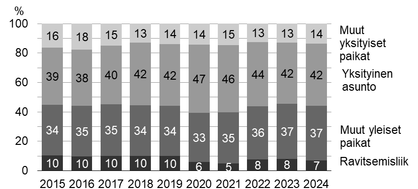

Yksityisessä asunnossa tehtyjen pahoinpitelyiden osuus on noussut vuosina 2015-2024. Osuus oli suurin vuonna 2020, viime vuosina osuus on laskenut.

**Kuvio 8** Pahoinpitelyrikosten tekopaikkojen osuudet kaikista pahoinpitelyrikosten tekopaikoista 2015–2024. *Lähde:* Tilastokeskus, rikos- ja pakkokeinotilasto (Tilastokeskus 2025a). Pyöristyksen takia kaikki luvut eivät summaudu sataan. Tarkastelusta on poistettu tuntemattomassa paikassa tapahtuneet teot, joiden määrä on hyvin vähäinen.

Yleisten paikkojen osalta pitkän ajan kehityksenä on ollut liikekeskuksissa ja yleisissä tilaisuuksissa tapahtuneiden pahoinpitelyjen määrän väheneminen. Tämä heijastanee vartioinnin ja kameravalvonnan tehostumista, mikä on johtanut päihtyneiden henkilöiden aiempaa nopeampaan poistamiseen kyseisistä tiloista. Ravitsemisliikkeissä tapahtuneiden tekojen absoluuttinen määrä ja osuus kaikista pahoinpitelyrikoksista on laskenut viime vuosina. Vuoden 2020 muutokset yksityisasuntojen ja ravitsemisliikkeiden osalta sen sijaan heijastelevat koronapandemian vaikutuksia. Ravitsemisliikkeiden aukioloa rajoitettiin, ja sosiaalinen kanssakäyminen rajoittui normaalia enemmän yksityisasuntoihin.

Taulukossa 2 puolestaan tarkastellaan poliisin kirjaamien pahoinpitelyjen ajallista sijoittumista viikonpäivien ja vuorokaudenaikojen mukaan. Siitä havaitaan, että valtaosa pahoinpitelyistä ajoittuu viikonloppuiltoihin ja aamuyön tunteihin. Tämä on myös alkoholipainotteisen yöelämän aktiivisinta aikaa. Arkipäivien osalta yleisin kirjaamisaika on klo 12 ja klo 15 välinen aika, johon vaikuttaa varsinkin koulujen tekemät ilmoitukset.

**Taulukko 2.** Pahoinpitelyt tapahtumaviikonpäivän ja kellonajan mukaan vuonna 2024.

|  | Maanantai | Tiistai | Keskiviikko | Torstai | Perjantai | Lauantai | Sunnuntai |
| --- | --- | --- | --- | --- | --- | --- | --- |
| 00:00 - 02:59 | 1,2 | 0,9 | 1,1 | 1,0 | 1,3 | 5,0 | 4,5 |
| 03:00 - 05:59 | 0,6 | 0,4 | 0,6 | 0,6 | 0,7 | 3,3 | 3,2 |
| 06:00 - 08:59 | 0,6 | 0,5 | 0,5 | 0,5 | 0,5 | 0,6 | 0,6 |
| 09:00 - 11:59 | 1,8 | 1,4 | 1,4 | 1,6 | 1,6 | 1,0 | 0,9 |
| 12:00 - 14:59 | 2,4 | 2,0 | 2,2 | 2,2 | 2,2 | 1,6 | 1,2 |
| 15:00 - 17:59 | 2,0 | 1,9 | 1,9 | 1,8 | 2,1 | 2,0 | 1,7 |
| 18:00 - 20:59 | 2,1 | 1,8 | 2,0 | 2,0 | 2,6 | 2,7 | 1,8 |
| 21:00 - 23:59 | 1,6 | 2,0 | 1,6 | 1,7 | 3,9 | 3,5 | 1,3 |
| Tuntematon | 1,1 | 0,6 | 0,5 | 0,6 | 0,6 | 0,4 | 0,4 |

Kuviossa 9 on tarkasteltu uhritutkimusten (Kansallinen rikosuhritutkimus 2012–2024) valossa väkivallan yleisyyttä sen tapahtumapaikan mukaan. Mittausten mukaan naisten väkivaltakokemukset tapahtuvat yleisimmin omassa asunnossa tai työpaikalla. Miesten osalta puolestaan korostuvat julkiset ja puolijulkiset tilat, mukaan lukien ravintolat ja baarit. Miesten kohdalla omassa asunnossa tapahtuneiden väkivaltakokemusten osalta palattiin vuonna 2023 vuoden 2020 tasolle. Naisten kohdalla vuonna 2023 uhriksi jouduttiin aiempia vuosia yleisemmin julkisessa tai puolijulkisessa tilassa.

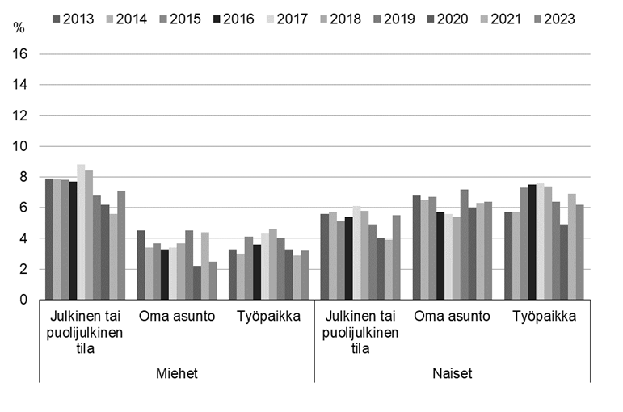

Miehet joutuvat tyypillisesti uhkailun ja väkivallan kohteeksi julkisessa tai puolijulkisessa tilassa. Naisilla oma asunto ja työpaikka ovat julkista tai puolijulkista tilaa tyypillisempiä paikkoja joutua väkivallan uhriksi.

**Kuvio 9** Eri ympäristöissä uhkailun ja väkivallan kohteeksi vuoden aikana joutuneet 15–74-vuotiaat sukupuolen mukaan vuosina 2013–2023, %. *Lähde*: Kansallinen rikosuhritutkimus 2012–2024

Kuviossa 10 on esitetty poliisin tilastoiman ryöstörikollisuuden tapahtumapaikat vuosina 2015–2024. Vuonna 2024 kaikkiaan 80 prosenttia ryöstöistä tapahtui yleisillä paikoilla. Yksityisasunnoissa tapahtuneiden ryöstöjen osuus oli 14 prosenttia ja liikekeskuksissa tapahtuneiden ryöstöjen osuus 10 prosenttia kaikista teoista. Näin ollen yleisillä paikoilla tapahtuneiden ryöstöjen osuus pysyä edeltävän vuoden tasolla. Samalla kuitenkin näyttää siltä, että kolmen viime vuoden osalta ryöstöjä tapahtuu aiempia vuosia hieman enemmän julkisissa tiloissa.

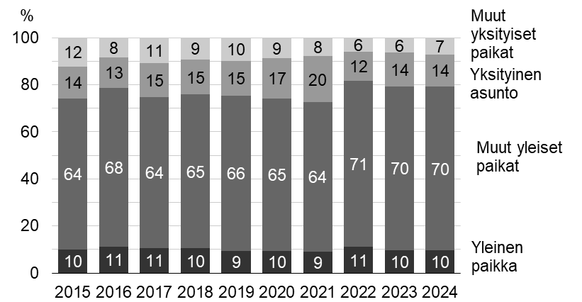

Yleisillä paikoilla tapahtuneiden ryöstöjen osuus kaikista ryöstöistä oli korkea vuonna 2024 (70%). Myös vuonna 2023 ryöstöjen osuus oli korkea 70%.

**Kuvio 10** Ryöstörikostenrikosten tekopaikkojen osuudet kaikista ryöstörikosten tekopaikoista 2015–2024. *Lähde*: Tilastokeskus, rikos- ja pakkokeinotilasto (Tilastokeskus 2025a)

### 4.4.3 Väkivalta ja alkoholi

Seuraavassa tarkastellaan alkoholin tai muiden päihteiden vaikutuksen alaisena olleiden määrää ja osuutta väkivaltarikoksissa. Erittelyt perustuvat poliisitilaston tietoihin siitä, kuinka moni selvitettyyn rikokseen syylliseksi epäilty oli tekohetkellä alkoholin tai muun päihteen vaikutuksen alaisena. Muu päihde viittaa huumeisiin ja lääkkeisiin. Muun päihteen vaikutuksen alaisina olleet sisältävät myös tekijät, jotka olivat tekohetkellä sekä alkoholin että muun päihteen vaikutuksen alaisina. Ilmaisun selkeyden vuoksi käytämme tilastokategoriasta “muu päihde” myös lyhyttä ilmausta “huume”.

Epäiltyjen päihtymystilaa koskevat tiedot perustuvat poliisien kentällä tekemiin havaintoihin. Kirjaamiskäytännöt vaihtelevat, joten tiedot voivat olla hyvinkin puutteellisia. Tästä syystä poliisitilastojen alkoholitietojen perusteella tehtäviin johtopäätöksiin alkoholisidonnaisen väkivallan määrästä ja kehityksestä tulee suhtautua varauksella varsinkin, kun voidaan havaita, että niiden tapausten määrä, joissa päihdetietoa ei ole käytössä, on kasvanut selvästi viimeisten vuosien aikana.

*Pahoinpitelyrikokset ja alkoholi*. Alkoholihumalassa tekohetkellä olleiden pahoinpitelyrikoksesta epäiltyjen määrä kasvoi voimakkaasti 1990-luvun puolivälissä, jonka jälkeen tilanne vakiintui uudelle tasolle (ks. tarkemmin Rikollisuustilanne 2012). Muun päihteen vaikutuksen alaisena olleiden tekijöiden osuus on pysynyt alhaisena – noin 2–3 prosenttia epäillyistä on ollut muun huumaavan aineen kuin alkoholin vaikutuksen alaisena (kuvio 11). Tilastojen valossa alkoholisidonnaisten rikosten osuus kaikista pahoinpitelyrikoksista on ollut selvästi laskusuuntainen viimeisten vuosien aikana. Kuten todettua, muutosta on ohjannut ennen kaikkea niiden tapausten määrä, joissa päihdetietoa ei ole käytettävissä. Samaan aikaan niiden tapausten osuus, joissa kirjattuna, että epäilty ei ollut päihteiden käytön alaisuudessa, on pysynyt samalla tasolla koko tarkastelujakson ajan.

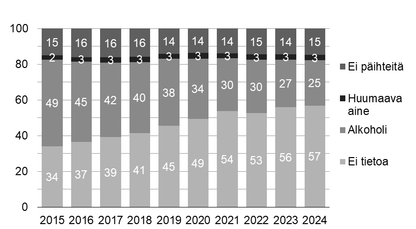

Vuonna 2015 ainoastaan 34 prosentissa pahoinpitelyrikoksista raportoitiin, että päihteiden osuudesta tekotilanteessa ei tietoa. Vuonna 2024 "ei tietoa" raportoitiin 57 prosentissa tapauksista.

**Kuvio 11** Päihteiden osuus pahoinpitelyrikosten tekotilanteissa: selvitettyihin rikoksiin syylliseksi epäillyt vuosina 2015−2024 (%). *Lähde:* Tilastokeskus, rikos- ja pakkokeinotilasto (Tilastokeskus 2025a).

*Ryöstörikokset ja alkoholi.* Alkoholin vaikutuksen alaisena ryöstön tehneiden määrä on poliisin tilastojen valossa vähentynyt viimeisen 10 vuoden aikana (kuvio 12). Myös huumausaineiden alaisena tehdyt teot vaikuttaisivat vähentyneen kahden viime vuoden aikana. Kuten edellä, myös ryöstöjen osalta muutosta on ohjannut varsinkin niiden tapausten määrä, joissa päihdetietoa ei ole käytettävissä. Samaan aikaan voidaan myös todeta, että niiden tapausten osuus, joissa kirjattuna, että epäilty ei ollut päihteiden käytön alaisuudessa, on pysynyt samalla tasolla viimeiset vuodet.

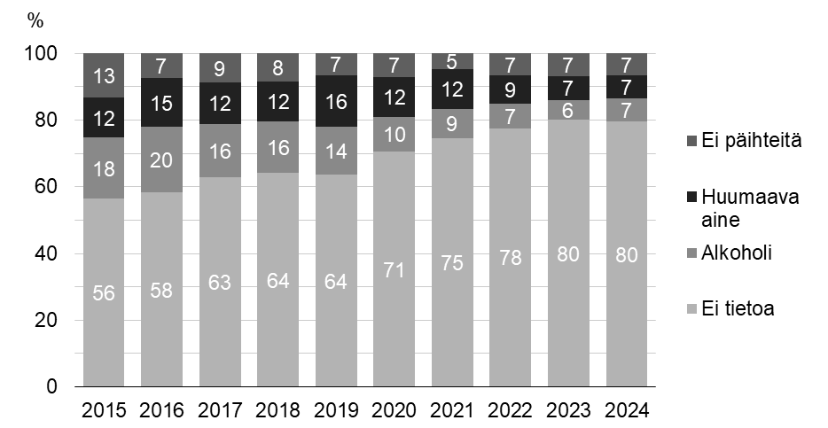

Vuonna 2015 56 prosentissa ryöstörikoksista raportoitiin, että päihteiden osuudesta tekotilanteessa ei tietoa. Vuonna 2024 "ei tietoa" raportoitiin 80 prosentissa tapauksista.

**Kuvio 12** Päihteet ryöstörikosten tekotilanteissa: selvitettyihin rikoksiin syylliseksi epäillyt vuosina 2015–2024 (%). *Lähde:* Tilastokeskus, rikos- ja pakkokeinotilasto (Tilastokeskus 2025a)

Ryöstörikosten kohdalla muun päihteen kuin alkoholin vaikutuksen alaisina olleiden epäiltyjen määrä kasvoi selvästi 2000-luvun alkuvuosina, mikä oli luultavasti yhteydessä niin sanottuun toiseen huumeaaltoon (Hakkarainen & Metso 2001). Huumeriippuvaiselle henkilölle ryöstö on rikoslajina houkutteleva, koska mahdollinen saalis on usein rahaa tai helposti muutettavissa rahaksi (Kinnunen 2001, 18). Viime vuosina huumausaineiden alaiset teot ovat kuitenkin vähentyneet, muutosta selittänee osin myös se, että aiempaa suurempi osuus ryöstörikosten epäillyistä on alle 15-vuotiaita.

### 4.4.4 Väkivaltarikosten selvitysaste ja ilmoitusalttius

*Selvitysaste.* Henkirikoksen yrityksistä on viime vuosina selvitetty 60–80 prosenttia tilastointivuoden aikana tapahtuneiden tapausten osalta (kuvio 13), mutta vuonna 2024 selvitysaste laski ensimmäistä kertaa kuluneen kymmenen vuoden aika alle 60 prosenttiin. Lopullinen selvitysprosentti on kuitenkin korkeampi, sillä osa loppuvuoden rikoksista selviää vasta seuraavan vuoden aikana.

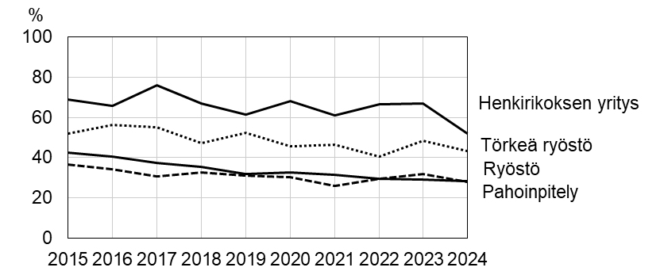

Sisältö kerrottu seuraavassa tekstiosuudessa.

**Kuvio 13** Eräät väkivaltarikokset: selvitettyjä rikoksia (%) vuoden aikana poliisin tietoon tulleista rikoksista vuosina 2015–2024. *Lähde:* Tilastokeskus, rikos- ja pakkokeinotilasto (Tilastokeskus 2025a)

Myös ryöstörikosten ja pahoinpitelyjen selvitysprosentti on hieman laskusuuntainen kuluneen kymmenen vuoden tarkastelujaksolla. Lopullinen selvitysaste on kuitenkin korkeampi kuin oheisen kuvion näyttämä kirjaamisvuoden aikana selvitettyjen rikosten osuus kirjatuista rikoksista. On mahdollista, että osa laskusta selittyy poliisin käsittely- ja tutkintaprosessien pitkittymisellä.

*Ilmoitusalttius.* Vuoden 2023 kansallisen rikosuhritutkimuksen mukaan vähintään läimäisyn käsittävää väkivaltaa kokeneista 18 prosenttia kertoi jonkin heihin kohdistuneen väkivallanteon tulleen poliisin tietoon (Beuker & Näsi 2024). Tämä on selkeästi enemmän kuin aiempina vuosina, sillä vuoden 2012 jälkeen vähintään läimäisyn sisältäneissä tapauksissa ilmoitusprosentti vakiintui pitkälti 10–13 prosentin tuntumaan.

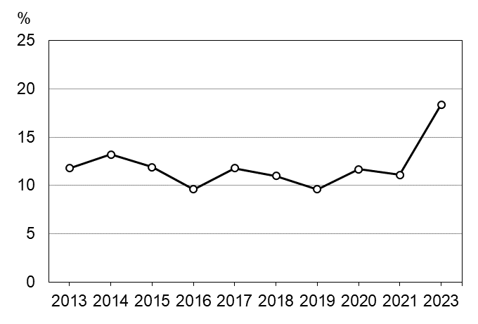

Sisältö kerrottu edellisessä tekstiosuudessa.

**Kuvio 14** Poliisille ilmoitettujen tapausten osuus kaikista sellaisista väkivaltatapauksista, joihin on liittynyt vähintään läimäisy (% 15–74-vuotiaista väkivallan uhreista). *Lähde:* KRT 2013–2024.

## 4.5 Väkivaltarikosten alueellinen jakautuminen

Pahoinpitelyrikosten alueellista jakautumista tarkastellaan seuraavassa poliisitilastotietojen pohjalta. Vaikka piilorikollisuuden osuus kokonaisrikollisuudesta todennäköisesti vaihteleekin kuntatyyppien ja maakuntien välillä, on epätodennäköistä, että pahoinpitelyrikollisuuden kaltaisessa massarikollisuudessa erot olisivat niin merkittäviä, että ne olennaisesti vääristäisivät poliisitilaston antamaa yleiskuvaa rikollisuuden alueellisesta jakautumisesta.

Tilastoitu pahoinpitelyrikollisuus on viimeisten kymmenen vuoden aikana kehittynyt pääpiirteittäin samansuuntaisesti kaikissa kuntatyyppiryhmissä (kuvio 15). Rikollisuustaso on korkein pääkaupunkiseudulla ja matalin maaseutumaisissa kunnissa. Vuosien 2014 ja 2021 välisenä aikana poliisin tietoon tulleiden pahoinpitelyrikosten taso oli varsin vakaa kaikissa kuntatyyppiryhmissä, kunnes vuonna 2022 ja 2023 nähtiin jälkeen kasvua kuntatyyppien kohdalla. Tosin kasvu ei ole jatkunut enää vuoden 2023 jälkeen.

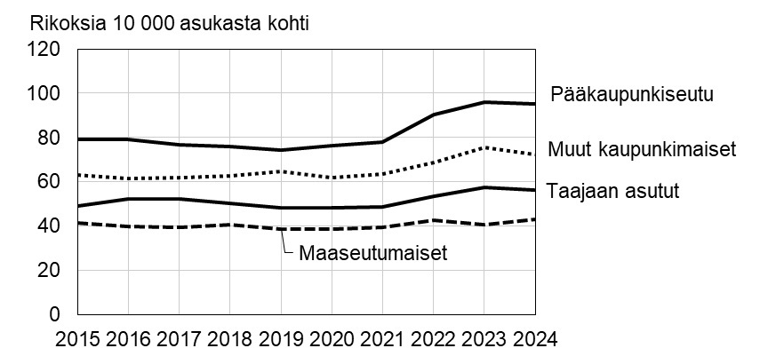

Pahoinpitelyrikoksissa korkein rikollisuustaso on pääkaupunkiseudulla. Toiseksi korkein taso on muissa kaupunkimaisissa kunnissa. Matalimmat tasot ovat taajaan asutuissa ja maaseutumaisissa kunnissa.

**Kuvio 15** Pahoinpitelyrikokset 10 000 asukasta kohti kuntaryhmän mukaan vuosina 2015–2024. *Lähteet:* Tilastokeskus, rikos- ja pakkokeinotilasto (Tilastokeskus 2025a); Tilastokeskus, väestörakenne (Tilastokeskus 2025c)

Seuraavassa tarkastellaan pahoinpitelyrikoksia poliisilaitosalueittain (taulukko 3). Poliisilaitosalueet noudattelevat maakuntarajoja; kuitenkin niin, että yksittäiset poliisilaitosalueet (pääkaupunkiseutua lukuun ottamatta) muodostuvat useista maakunnista. On syytä huomioida, että Helsinki poikkeaa muista alueista siinä, että alue muodostuu kokonaisuudessaan kaupunkimaisesta ympäristöstä. Uudenmaan osalta huomionarvoista on, että Itä-Uudenmaan poliisilaitosalue ei vastaa vuonna 1997 lakkautettua Itä-Uudenmaan maakuntaa, vaan pitää sisällään myös Vantaan.

**Taulukko 3** Pahoinpitelyrikokset 100 000 asukasta kohti poliisilaitosalueittain 2015–2024

[output not shown]

*Lähteet:* Tilastokeskus, rikos- ja pakkokeinotilasto (Tilastokeskus 2025a); Tilastokeskus, väestörakenne (Tilastokeskus 2025c).

Vuosien 2018–2024 Kansallisessa rikosuhritutkimuksissa (Danielsson & Näsi 2019; Danielsson & Näsi 2020; Näsi & Kolttola 2021; Kolttola & Näsi 2022; Beuker & Näsi 2024) on tarkasteltu vamman aiheuttaneen väkivallan yleisyyttä niin ikään poliisilaitosalueen mukaan (kuvio 16). Tarkastelussa vuosien 2018–2023 aineistot on yhdistetty. Estimaatit olivat korkeimpia Itä-Suomen, Hämeen ja Pohjanmaan poliisilaitosalueilla ja matalimpia Itä- ja Länsi-Uudenmaan ja Oulun poliisilaitosalueilla. Alueiden välillä ei kuitenkaan ollut tilastollisesti merkitsevää eroa, joten voidaan sanoa, että uhrikyselyiden mukaan väkivaltakokemukset olivat eri poliisilaitosalueilla verrattain samalla tasolla. Kuten edellä on todettu, eivät poliisilaitosalueiden väliset erot myöskään viranomaisten tietoon tulleessa pahoinpitelyrikollisuudessa ole kovin suuria. Kyselypohjaisessa indikaattorissa, jossa väkivaltakokemukset tilastoituvat asuinkunnan mukaan, Helsinki ei myöskään eroa olennaisesti muista alueista. Sekä kyselylähteet että viranomaislähteet siis osoittavat, että poliisilaitosalueiden välillä ei Helsingin tilastoitua pahoinpitelyrikollisuutta lukuun ottamatta ole olennaisia eroja väkivallan esiintyvyydessä. Erot kuitenkin korostuvat maakunta- ja kuntatasolla.

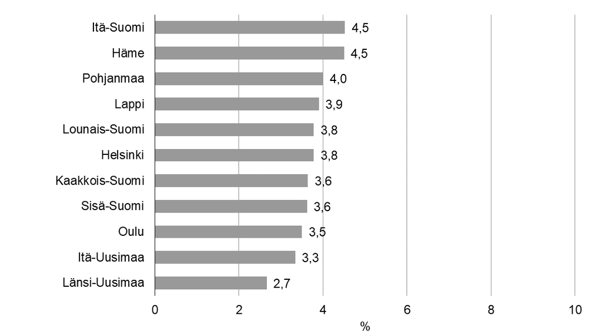

Vuosina 2018-2023 4,5% Itä-Suomen 15-74-vuotiaista joutui vamman aiheuttaneen väkivallan kohteeksi. Vähiten uhrikokemuksia raportoitiin Länsi-Uudellamaalla (2,7%).

**Kuvio 16** Vamman aiheuttaneen väkivallan kohteeksi joutuneet poliisilaitosalueen mukaan vuosina 2018–2023 (% 15–74-vuotiaista). *Lähde*: Kansallinen rikosuhritutkimus 2018–2024.

## 4.6 Väkivallan pelko

Uhritutkimuksissa on vuodesta 1988 alkaen kysytty, onko vastaaja huolissaan siitä, että joutuu väkivallan kohteeksi. Vuoden 2023 Kansallisen rikosuhritutkimuksen mukaan 13 prosenttia 15–74-vuotiaista vältti jotakin kodin lähellä olevaa turvattomaksi kokemaansa aluetta (Beuker & Näsi 2024). Naisista näin teki selvästi useampi (17 %) kuin miehistä (10 %). Mitä kaupunkimaisemmasta ympäristöstä oli kysymys, sitä tyypillisempää oli turvattomaksi koettujen alueiden välttäminen.

Väkivallan kohteeksi joutumisen pelosta kysyttiin kolmen eri tekomuodon osalta (perheväkivalta, työpaikkaväkivalta ja väkivalta kodin ulkopuolella iltaisin). Kysytyistä pelon muodoista selvästi yleisintä oli pelkääminen kodin ulkopuolella iltaisin. Tällaisesta huolesta raportoi 31 prosenttia vastaajista. Noin joka seitsemäs (15 %) vastaajista ilmoitti pelänneensä väkivallan kohteeksi joutumista työpaikalla tai työtehtävissä. Harvinaisinta oli perheväkivallan pelko: viisi prosenttia oli pelännyt joutuvansa väkivallan kohteeksi perheenjäsenen taholta. Naiset kantoivat miehiä enemmän huolta väkivallan kohteeksi joutumisesta kaikissa kysytyissä ympäristöissä (Beuker & Näsi 2024).

Kuviosta 17 ilmenee, miten väkivallan pelko on muuttunut viimeisen lähes kolmen vuosikymmenen aikana. Kuvioita tarkasteltaessa on jälleen pidettävä mielessä uhritutkimusten tiedonkeruumenetelmän vaihtuminen vuoden 2012 mittauksesta alkaen, joka on todennäköisesti vaikuttanut estimaattien tasoon. Huolessa joutua väkivallan kohteeksi illalla kodin ulkopuolella liikkuessa on tapahtunut selviä muutoksia tarkastelujaksolla. Jaksolla 1988–1997 pelko ja huolestuneisuus lisääntyivät, mutta vähenivät jaksolla 1997–2006. Tämän jälkeen pelon yleisuus näyttää vakiintuneen jokseenkin nykytasolle noin 30 prosenttiin (26–35 prosenttia vuosina 2012–2023).

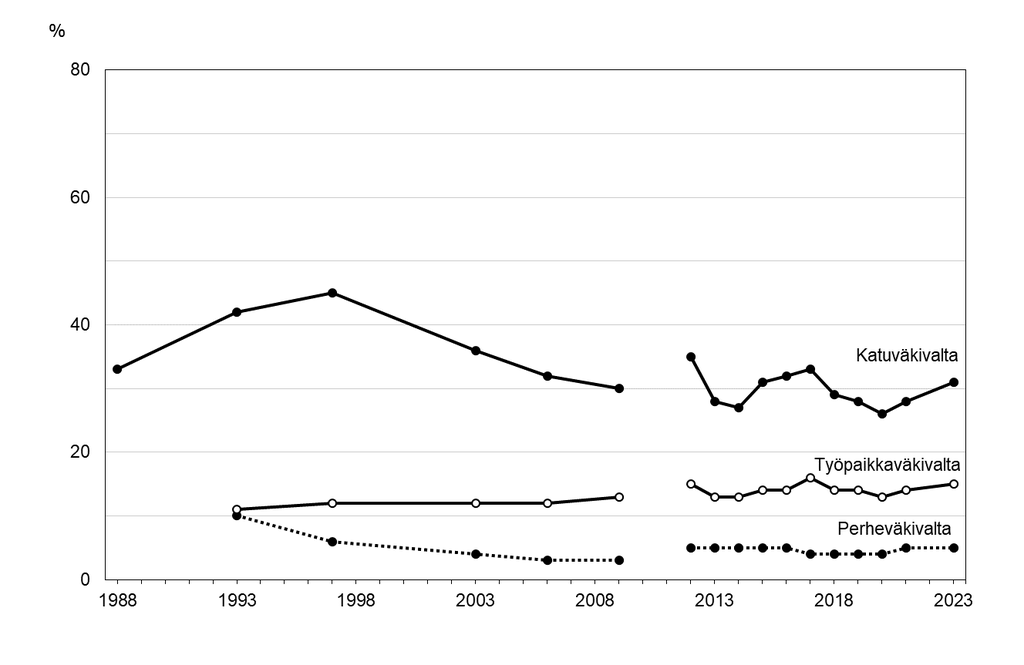

Katuväkivaltaa pelätään enemmän kuin työpaikka- tai perheväkivaltaa.

**Kuvio 17** Väkivallan kohteeksi joutumisesta jokseenkin tai erittäin huolestuneita (1988–2009) ja väkivaltaa pelänneet (2012–2023), % 15–74-vuotiaista. *Lähteet*: Sirén ym. 2010 ja KRT 2012–2024.

Uhritutkimuksissa on myös kysytty erikseen perheväkivallan ja työpaikkaväkivallan pelkoa. Huoli siitä, että joutuu perheväkivallan kohteeksi, vähentyi 1990-luvulla ja sen jälkeen vakiintui nykyiselle, verrattain alhaiselle tasolle. Työpaikkaväkivallan pelko on pysynyt kokonaisuutena arvioiden samalla tasolla (Sirén ym. 2010; Beuker & Näsi 2024).

## 4.7 Väkivaltaan liittyvät terveydenhuollon rekisterimerkinnät

Väkivaltaan liittyviä terveydenhuollon rekisterimerkintöjä voidaan tarkastella terveydenhuollon hoitoilmoitusrekisterin (Terveys-Hilmo) ja perusterveydenhuollon avohoidon käynteihin liittyvän hoitoilmoitusrekisterin (Avohilmo) perusteella. Tässä esiteltävät hoitoilmoitusrekisterin tiedot sisältävät tiedot julkisen erikoissairaanhoidon avohoidon käynneistä ja alkaneista vuodeosaston hoitojaksoista. Avohilmo sen sijaan sisältää tiedot perusterveydenhuollon avohoidon käynneistä, ja nämä raportoidaan tässä osiossa erikseen. Lisäksi lopussa tarkastellaan ampuma-aseisiin liittyvää väkivaltaa hoitoilmoitusrekisterin perusteella.

Käyntien tai yhteydenottojen yhteydessä tietoihin merkitään käynnin syyksi ICD10-koodien mukainen primaaridiagnoosi, joka kuvaa terveydenhuollon piiriin hakeutumisen pääasiallista syytä. Väkivaltaan liittyvät ICD-10-koodit (X85-Y09) merkitään sekundaaridiagnooseina, jotka edellyttävät myös primaaridiagnoosin (THL 2011, s. 785). Käytännössä tämä tarkoittaa sitä, että hoitoon hakeutumisen primaaridiagnoosi on väkivallasta seurannut vamma, jonka lisäksi vamman syy (esim. väkivalta) merkitään sekundaaridiagnoosina. Tämä diagnoosien merkitsemisen järjestys voi johtaa siihen, että sekundaaridiagnooseissa on jonkin verran aliraportointia.

Erikoissairaanhoidon käyntikertojen perusteella miehet joutuvat väkivallan takia huomattavasti naisia useammin terveydenhuollon piiriin (kuvio 18). Miehillä väkivaltaan liittyviä erikoissairaanhoidon avohoidon käyntikertoja oli vuonna 2024 hieman edellisvuotta vähemmän (7681), naisilla 3041. Miesten käyntimäärissä on jonkin verran vuositasoista vaihtelua, kun taas naisten osalta vuosittaiset käyntimäärät ovat olleet melko tasaisia vuodesta 2020 eteenpäin.

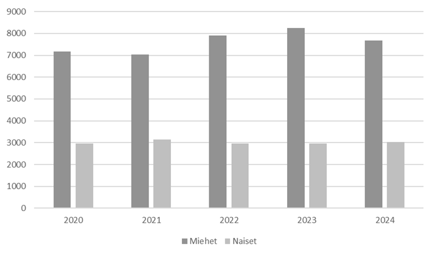

Väkivaltaan liittyvät erikoissairaanhoidon käyntikerrat sukupuolen mukaan ovat pysyneet suhteellisen vakaana vuosien 2020 ja 2024 välillä

**Kuvio 18** Väkivaltaan liittyvät erikoissairaanhoidon käyntikerrat sukupuolen mukaan 2020–2024.

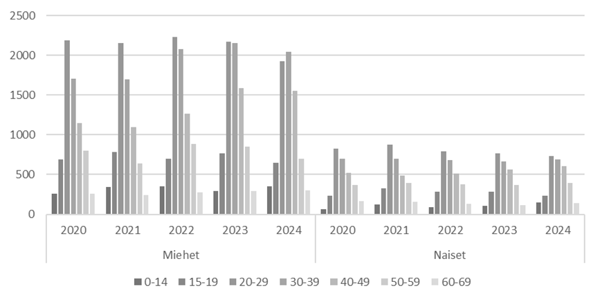

Myös Väkivaltaan liittyvät erikoissairaanhoidon käyntikerrat sukupuolen ja iän mukaan ovat pysyneet suhteellisen vakaana vuosien 2020 ja 2024 välillä. Nuoret aikuiset miehet ovat tyypillisimpiä väkivallan uhreja hoitoilmoitusjärjestelmän tietojen mukaan

**Kuvio 19** Väkivaltaan liittyvät erikoissairaanhoidon käyntikerrat sukupuolen ja iän mukaan 2020–2024.

Alkaneiden vuodeosaston hoitojakson suhteen tilanne näyttää sekä sukupuolten välisten erojen että ikäryhmien suhteen samalta kuin erikoissairaanhoidon käynneissä (kuvio 20). Miehillä väkivallasta johtuvia vuodeosaston hoitojaksoja oli 844 vuonna 2024, naisilla 218. Naisten osalta ikäryhmien väliset erot vuodeosaston hoitojaksoissa ovat miehiin verrattuna tasaisempia.

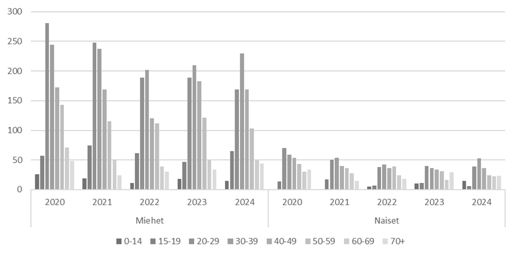

Nuorilla miehillä on eniten vuodenosaston hoitojaksoja. Sukupuolen ja iän mukaan vuodeosaston hoitojaksot ovat pysyneet suhteellisen vakaana vuosina 2020-2024

**Kuvio 20** Väkivaltaan liittyvät vuodeosaston hoitojaksot sukupuolen ja iän mukaan 2020–2024.

Perusterveydenhuollon avohoidon käyntikerroissa (Avohilmo) sukupuolten välinen ero on tasaisempi kuin hoitoilmoitusjärjestelmän kokonaiskuvassa (kuvio 21). Hoitoilmoitusjärjestelmän käyntikerroissa on mukana esimerkiksi erikoissairaanhoidon käyntikerrat, kun taas Avohilmon tiedot sisältävät ainoastaan perusterveydenhuollon avohoidon käynnit. Avohilmon merkinnät voivat kertoa siitä, että miesten ja naisten välinen ero lievemmän väkivallan uhrikokemuksissa on vakavaa väkivaltaa pienempi myös terveydenhuollon rekisteritietojen perusteella.

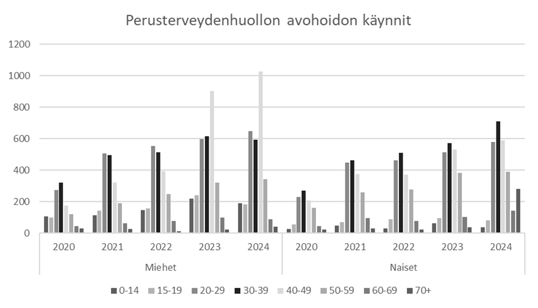

Väkivaltaan liittyvät perusterveydenhuollon käynnit ovat yleisimpiä 20-49 vuotiailla miehillä.

**Kuvio 21** Väkivaltaan liittyvät perusterveydenhuollon avohoidon (Avohilmo) käynnit sukupuolen ja iän mukaan 2020–2024.

### 4.7.1 Ampuma-aseisiin liittyvät hoitoilmoitusjärjestelmän merkinnät

Hoitoilmoitusjärjestelmässä on eroteltavissa ampuma-aseisiin liittyvät käyntikerrat vuosien 2015 ja 2024 välillä (taulukko 4 ja 5). Ampuma-aseisiin liittyvien hoitoilmoitusjärjestelmän merkintöjen suhteen tarkastellaan vuodesta 2015 alkavaa aikasarjaa, koska näin vakaviin tapauksiin voi olettaa liittyvän vähemmän merkitsemiskäytäntöihin liittyviä muutoksia ja eroja. Ampuma-aseisiin liittyvät hoitoilmoitusjärjestelmän merkinnät on poimittu ICD-10-koodien X93-X95 (Murha, tappo tai muu tahallinen pahoinpitely aseella), Y22-Y24 (Aseen laukauksesta vahingoittuminen, tahallisuus epäselvä) ja X74 (Tahallinen itsensä ampuminen) perusteella.

Tilastojen perusteella havaitaan selvä ero sukupuolten välillä, sillä vuonna 2024 miesten kohdalla merkintöjä oli yhteensä 746 ja naisten kohdalla 128. Vuonna 2024 käyntikertojen määrä oli kymmenen vuoden tarkastelussa selvästi korkein. Vuosien 2015–2024 osalta käyntikertojen määrissä havaitaan jonkin verran vuosittaista vaihtelua, mutta mitään selkeämpää trendiä ei ole havaittavissa. On kuitenkin syytä huomioida, että sama henkilö voi esiintyä tilastossa useita kertoja. On esimerkiksi todennäköistä, että ampuma-aseisiin liittyvä väkivalta voi vaatia useita käyntikertoja, jos väkivalta ei johda kuolemaan. Näin ollen tässä raportoitavat tilastot kuvaavat terveydenhuollon kuormitusta ampuma-aseisiin liittyen. Kyse ei siis ole ampuma-aseisiin liittyvän väkivallan takia terveydenhuoltoon vuosittain hakeutuvien henkilöiden määristä.

**Taulukko 4** Ampuma-aseisiin liittyvän väkivallan merkinnät hoitoilmoitusjärjestelmässä 2015–2024 (miehet).

|  | **2015** | **2016** | **2017** | **2018** | **2019** | **2020** | **2021** | **2022** | **2023** | **2024** |
| --- | --- | --- | --- | --- | --- | --- | --- | --- | --- | --- |
| 0–14 | 17 | 11 | * | 12 | 6 | * | 7 | * | 7 | * |
| 15–29 | 91 | 127 | 139 | 143 | 168 | 138 | 140 | 135 | 149 | 259 |
| 30–64 | 289 | 372 | 347 | 413 | 367 | 270 | 281 | 250 | 278 | 402 |
| 65+ | 45 | 37 | 33 | 51 | 53 | 36 | 30 | 64 | 61 | 81 |
| **Yhteensä** | 442 | 547 | 523 | 619 | 594 | 447 | 458 | 452 | 495 | 746 |

**Taulukko 5** Ampuma-aseisiin liittyvän väkivallan merkinnät hoitoilmoitusjärjestelmässä 2015–2024 (naiset).

|  | **2015** | **2016** | **2017** | **2018** | **2019** | **2020** | **2021** | **2022** | **2023** | **2024** |
| --- | --- | --- | --- | --- | --- | --- | --- | --- | --- | --- |
| 0–14 | * | * | * | 9 | * | * | 22 | 0 | * | 22 |
| 15–29 | 35 | 35 | 47 | 26 | 35 | 22 | 32 | 18 | 19 | 15 |
| 30–64 | 20 | 11 | 32 | 63 | 56 | 40 | 34 | 46 | 64 | 88 |
| 65+ | 6 | 5 | * | 8 | * | 5 | * | * | * | * |
| **Yhteensä** | 62 | 52 | 84 | 106 | 95 | 67 | 90 | 66 | 83 | 128 |

## 4.8 Lähteet

Aaltonen, Mikko. 2010. Nuorten aikuisten koulupudokkuus, työttömyys ja väkivaltarikollisuus – väkivallan tekijät ja uhrit kansallisesti edustavan rekisteriaineiston valossa. Oikeus 2010(3): 220–247 https://www.edilex.fi/oikeus/7375.

Aaltonen, Mikko. 2013. *Socioeconomic differences in crime and victimization. A register-based study.* Oikeuspoliittisen tutkimuslaitoksen julkaisuja 263. Helsinki: Oikeuspoliittinen tutkimuslaitos. http://hdl.handle.net/10138/152463.

Beuker, Aaro & Näsi, Matti. 2024. *Suomalaiset väkivallan ja omaisuusrikosten kohteena 2023 – Kansallisen rikosuhritutkimuksen tuloksia.* Katsauksia 61 / 2024. Helsinki: Kriminologian ja oikeuspolitiikan instituutti.

Danielsson, Petri & Näsi, Matti. 2019. *Suomalaiset väkivallan ja omaisuusrikosten kohteena 2018 – Kansallisen rikosuhritutkimuksen tuloksia.* Katsauksia 35/2019. Helsinki: Kriminologian ja oikeuspolitiikan instituutti.

http://hdl.handle.net/10138/305388.

Danielsson, Petri & Näsi, Matti. 2020. *Suomalaiset väkivallan ja omaisuusrikosten kohteena 2019 – Kansallisen rikosuhritutkimuksen tuloksia.* Katsauksia 43/2020. Helsinki: Kriminologian ja oikeuspolitiikan instituutti.

Näsi, Matti & Ilari Kolttola. *Suomalaiset väkivallan ja omaisuusrikosten kohteena 2020 – Kansallisen rikosuhritutkimuksen tuloksia.* Katsauksia 48 / 2021. Helsinki: Kriminologian ja oikeuspolitiikan instituutti.

Hakkarainen, Pekka & Leena Metso. 2001. Onko huumeiden käytön yleisyys taittumassa? Vuoden 2000 huumekyselyn tulokset. *Yhteiskuntapolitiikka* 66(3): 277–283.

Heiskanen, Markku. 1998. *En fråga, tre metoder.* Helsingfors: Statistikcentralen.

Kinnunen, Aarne. 2001. *Huumausainerikoksiin syyllistyneiden rikosura ja sosioekonominen asema.* Oikeuspoliittisen tutkimuslaitoksen julkaisuja 182. Helsinki: Oikeuspoliittinen tutkimuslaitos.

Kivivuori, Janne, toim. 2009. *Nuorten syrjäytyminen ja rikollisuus. Suomessa tehdyn tutkimuksen ja sen katvealueiden kartoitusta.* Oikeuspoliittisen tutkimuslaitoksen tutkimustiedonantoja 94. Helsinki: Oikeuspoliittinen tutkimuslaitos. http://hdl.handle.net/10138/152521.

Kolttola, Ilari & Matti Näsi. *Suomalaiset väkivallan ja omaisuusrikosten kohteena 2021 – Kansallisen rikosuhritutkimuksen tuloksia.* Katsauksia 51 / 2022. Helsinki: Kriminologian ja oikeuspolitiikan instituutti.

Laaksonen, Seppo & Markku Heiskanen. 2014. Comparison of Three Modes for a Crime Victimization Survey. *Journal of Survey Statistics and Methodology* 2(4): 459–483. https://doi.org/10.1093/jssam/smu018.

Lehti, Martti. 2020. *Henkirikoskatsaus 2020*. Helsingin yliopisto, Kriminologian ja oikeuspolitiikan instituutti, Katsauksia: 41/2020

Rikollisuustilanne 2014. Rikollisuus ja seuraamusjärjestelmä tilastojen valossa.  
Helsinki: Oikeuspoliittinen tutkimuslaitos. http://hdl.han-  
dle.net/10138/164434

Sirén, Reino. 2011. Uuden rikosuhritutkimuksen kehittäminen. Oikeuspoliittisen tutkimuslaitoksen tutkimustiedonantoja 109. Helsinki: Oikeuspoliittinen tutkimuslaitos. http://hdl.handle.net/10138/152504.

Sirén, Reino, Mikko Aaltonen & Juha Kääriäinen. 2010. *Suomalaisten väkivaltakokemukset 1980–2009.* Oikeuspoliittisen tutkimuslaitoksen tutkimustiedonantoja 103. Helsinki: Oikeuspoliittinen tutkimuslaitos. http://hdl.handle.net/10138/152511.

Sirén, Reino & Päivi Honkatukia, toim. 2005. *Suomalaiset väkivallan uhreina. Tuloksia 1980–2003 kansallisista uhrihaastattelututkimuksista.* Oikeuspoliittisen tutkimuslaitoksen julkaisuja 216. Helsinki: Oikeuspoliittinen tutkimuslaitos.

Smolej, Mirka. 2014. *Kenelle väkivaltarikokset kasautuvat Suomessa? Poliisin tietoon tullut toistuva väkivalta ja sen uhrit.* Yhteiskuntapolitiikka 79 (2014):1

THL – Terveyden ja hyvinvoinnin laitos. 2011. Tautiluokitus ICD-10. Saatavilla verkossa: https://urn.fi/URN:NBN:fi-fe201205085423

Tilastokeskus. 2025a. Rikos- ja pakkokeinotilasto. Helsinki: Tilastokeskus.

https://stat.fi/til/rpk/

Tilastokeskus. 2025b. Työssäkäynti. Helsinki: Tilastokeskus.

https://www.stat.fi/til/tyokay/

Tilastokeskus. 2025c. Väestörakenne. Helsinki: Tilastokeskus.

https://www.stat.fi/til/vaerak/